```python
import numpy as np
from sympy import Matrix, sqrt, Rational
from IPython.display import Video, Image, display
import matplotlib.pyplot as plt
from mpl_toolkits.mplot3d import Axes3D
```

# Rotor Pathing

### A VTOL plane is being designed in order to transition two rotors from pointing in the $[e_3]^E$ direction, where $E$ denotes the earth fixed frame. Over the course of some time interval $t^*$, the rotor-fixed frame $R$ rotates 90 degrees about $[e_1]^E$ at a wing joint.

### During this transition, it is important to ensure that no lift force generated by the rotors is produced in the $[e_2]^B$ direction, where $B$ denotes a body fixed frame. Any forces in this direction correspond to an unwanted force, putting the plane in either tension or compression.

### We establish the normalized force vector to point purely in the $[e_3]^R$ direction:

### $[F_{rotor}]^E = \begin{bmatrix}\ 0 \\0 \\ 1 \end{bmatrix}$

### We then define the angles the coordinate systems will rotate with. Since we know the $[F_{rotor}]^E$ vector points exclusively in the Rotor Fixed Frame's $[e_3]^R$ direction, we describe the rotation of the Rotor Frame as a postive rotation about the $[e_2]^E$ direction, or a pitch.

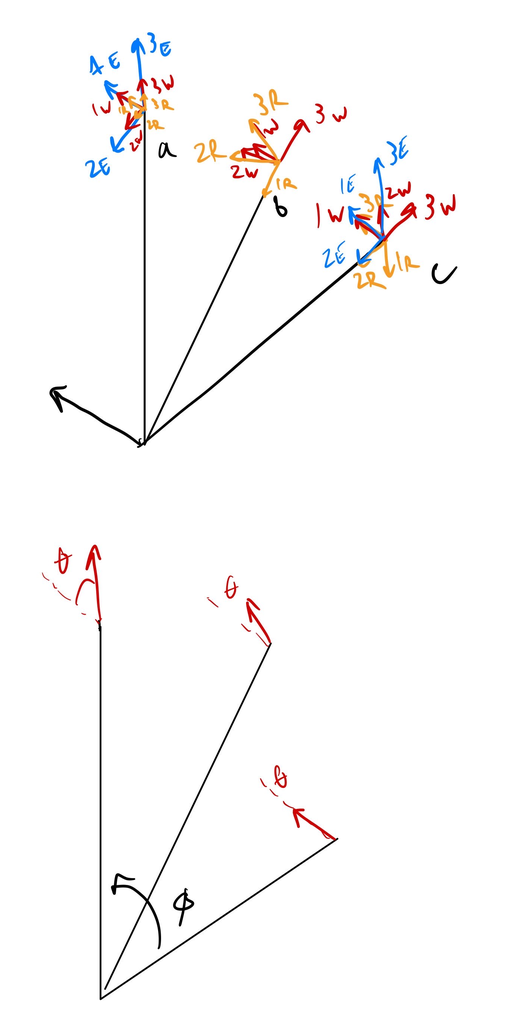

```python
display(Image(filename="coordinates.png", width=400))
```

### We then multiply our normalized Force vector to get the direction of it in the Wing-frame.

### $[F_{rotor}]^W = [T]_{WR} [F_{rotor}]^R = \begin{bmatrix}\ \sin(\theta) \\ \cos(\theta) \sin(\phi) \\ \cos(\phi) \cos(\theta) \end{bmatrix}$

### We can now plot this in 3D space. We yield a spherical quadrant with the bounds of a pitch and roll varying from 0 to $\pi/2$. Any path drawn on this quadrant is a valid solution to the problem, but we are bounded by a couple restraints.

### First, we want both angles to be zero at the beginning of the transition, and $\pi/2$ at the end. Second, we want both to be changing at roughly the same rate, as it makes sense to include some portion of lift from the wing motors pointing upwards before the wings are fully deployed.

### A simple and reasonable constraint is to establish that the angles will increase at the same rate. This reduces our solutions to a singular path, a semi-circular arc tilted at 45 degrees from the horizontal. We have now defined our motion.

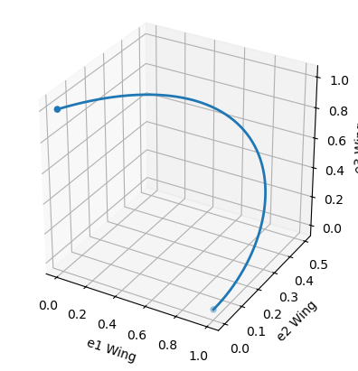

```python
psi = np.linspace(0, np.pi/2, 200)

x = np.sin(psi)
y = np.cos(psi)*np.sin(psi)
z = np.cos(psi)**2

fig = plt.figure()
ax = fig.add_subplot(111, projection='3d')
ax.plot(x, y, z, linewidth=2)      # path of e3_R expressed in wing frame
ax.scatter([0,1],[0,0],[1,0])      # start (0,0,1) and end (1,0,0)
ax.set_xlabel('e1 Wing'); ax.set_ylabel('e2 Wing'); ax.set_zlabel('e3 Wing')
ax.set_box_aspect([1,1,1])
plt.show()
```

```python
Video("translationdemo.mp4", embed=True, width=600)
```

[video not shown]

# Servo Force Calculation

### We will now define a new servo-fixed frame, $S$. At the beginning of time interval $t^*$ at $t=0$, the rotor arm begins to travel along its semi-circular path due to an input of the servo. The rotor spins at some $\omega$, and the triad $[e_1]^R, [e_2]^R, [e_3]^R$ precesses in the $[e_3]^S$ direction with an angular velocity $\Omega$.

### The total angular velocity of the rotor can be defined as

### $\omega_{rotor} = [\omega]^R + [\Omega]^S$

### In order to calculate the angular momentum in the servo-fixed frame, we must use transformation matricies.

### The tranformation matrix is defined as

### $$ [T]^{SR} = \begin{bmatrix} c_\psi c_\theta & c_\psi s_\theta s_\phi - s_\psi c_\phi & c_\psi s_\theta c_\phi + s_\psi s_\phi \\ s_\psi c_\theta & s_\psi s_\theta s_\phi + c_\psi c_\phi & s_\psi s_\theta c_\phi - c_\psi s_\phi \\ -s_\theta & c_\theta s_\phi & c_\theta c_\phi \end{bmatrix} $$

### We can now fully express our system's total angular velocity in the servo fixed frame.

### $[\omega_{rotor}]^S = [T]^{SR} \, [\omega]^R + [\Omega]^S$

### We may also calculate the angular momentum of the system about point $A$, we just need to perform a transformation on the Inertia tensor.

### $[L]^S = [I_A]^S \, [\omega_{rotor}]^S $

### $[L]^S = [T]^{SR} \, [I_A]^R \, [\overline{T}]^{SR} \, [\omega_{rotor}]^S $

### When the rotor arm precesses due to the servo, we can now calculate the torque produced. The Gyroscopic couple $G$ represents the torque required to change the angular momentum of the system $L$ at the rate of procession $\Omega$.

### $[G]^S = [\Omega]^S \times [L]^S$

# Calculation

```python
s_r = Matrix([ [0],[0],[0.05192]]) #DISPLACEMENT VECTOR IN ROTOR-FIXED FRAME
R=0.1016 #RADIUS OF PROPELLER
M=0.01051 #MASS OF PROPELLER
omega_prop = Matrix([[0], [0], [2*np.pi*8000/60]]) #THEORETICAL MAX RPM OF MOTOR CONVERTED TO RAD/S
omega_precess = Matrix([[0], [0], [np.pi]]) #THEORETICAL FASTEST SPEED WE WILL DEPLOY THE SERVO
T_sr = Matrix([[0.7071, 0, 0.7071], [0, 1, 0], [-0.7071, 0, 0.7071]]) #TRANSFORMATION MATRIX CORRESPONDING TO PITCH OF pi/4
a, b, c = s_r[0], s_r[1], s_r[2] # RETRIEVE COMPONENTS OF DISPLACEMENT IN ROTOR-FIXED FRAME
I_A_R = Matrix([ #INERTIA TENSOR WITH PARALLEL AXIS THEOREM IN ROTOR FIXED FRAME
    [(1/6)*M*R**2 + M*(b**2 + c**2), -M*a*b, -M*a*c],
    [-M*a*b, (1/6)*M*R**2 + M*(a**2 + c**2), -M*b*c],
    [-M*a*c, -M*b*c, (1/3)*M*R**2 + M*(a**2 + b**2)]
])
I_A_S = T_sr * I_A_R * T_sr.T #TRANSFORM INERTIA TENSOR BACK TO SERVO FIXED FRAME
L_S = I_A_S*(T_sr * omega_prop + omega_precess) #CALCULATE ANGULAR MOMENTUM IN SERVO FIXED FRAME
G = omega_precess.cross(L_S) #CALCULATE GYROSCOPIC COUPLE IN SERVO FIXED FRAME
print('The resulting Torque Required is ', "%.5f" % G[1], 'Nm')
```

```
The resulting Torque Required is  0.06725 Nm
```